# DS202: Final Project Report

Group 4: MyTien Kien, Tanner Dunn, Saketh Jonnadula, Ryan Pate

4/26/2021

### **Description of Data**

https://www.kaggle.com/yamaerenay/spotify-dataset-19212020-160k-tracks/version/10

These variables may include: danceability, valence, liveness, loudness, acousticness, energy… and so on.

Out of those variables, we used “popularity” the most, to help us define the success of a song in the music industry (through the eyes of Spotify). We were given 5 different .csv files that were sorted based on year, genre and more.

### **Questions Raised**

- Does the popularity depend on the year it was released?
- Does the popularity of a song depend on the danceability or energy?
- What were the 5 most popular songs in 2020? How do these songs compare to the top 5 in 2010?
- Analyze how song trends such a danceability, energy, loudness, etc… changed throughout each year.
- What is the relationship between the acousticness and the tempo of a song?
- Are explicit songs more popular than non-explicit songs?
- Who are the most popular one hit wonders?
- How has Post Malone’s (Tanner’s favorite artist) popularity changed over the past few years?
- What are/were the most popular genres in the past century?

### **Pipeline for Obtaining/Cleaning Dataset**

As mentioned above, we received this dataset from kaggle, an online community full of data scientists and machine learning practitioners. The dataset is an old version (it was the most recent one when we found it), so it only includes songs up to early 2021 (January), with over 175,000 songs.

For cleaning, we haven’t had to do much besides dropping the NA values for every .csv file we were given. The csv files we were given were ordered by a specific variable, such as, song ID, year, genre and artist. Since we each did our own analysis, we all cleaned it specific to what we needed for our question.

### **Data Wrangling and Visualization**

As far as data wrangling and data visualization goes, We each did our own as needed for our individual problems. We made sure to explain this out below as it pertained to each question. For a quick summary, common practices included using group_by, summarizing popularity as the “mean(popularity)” and filtering as necessary. Visualization wise our group utilized many techniques such as barplots, histograms, line graphs, tables and many more.

### **Answers for Questions Raised**

```r
library(ggplot2)
library(tidyr)
library(dplyr)

main <- readr::read_csv('./excel_files/data.csv')
by_artist <- readr::read_csv('./excel_files/data_by_artist.csv')
by_genre <- readr::read_csv('./excel_files/data_by_genres.csv')
by_year <- readr::read_csv('./excel_files/data_by_year.csv')
main <- drop_na(main)

by_year <- drop_na(by_year)
by_genre <- drop_na(by_genre)
```

**1. Does the popularity depend on the year it was released?**

```r
q1 <- by_year %>%
        group_by(year) %>%
        summarize(popularity = mean(popularity)) %>%
        arrange(desc(popularity)) %>%
        head(n = 20)
q1
```

```
## # A tibble: 20 x 2
##     year popularity
##    <dbl>      <dbl>
##  1  2001       50.9
##  2  2004       48.0
##  3  2000       46.3
##  4  2003       45.8
##  5  2002       45.7
##  6  1999       45.2
##  7  1998       44.9
##  8  1997       44.6
##  9  1994       44.4
## 10  1995       44.2
## 11  1996       44.0
## 12  2006       42.7
## 13  2007       42.6
## 14  1992       42.5
## 15  1993       42.3
## 16  2005       42.1
## 17  1990       40.2
## 18  1987       39.0
## 19  1991       39.0
## 20  1988       38.9
```

**2. Does the popularity of a song depend on the danceability or energy?**

```r
main_danceability_ave <- mean(main$danceability)
main_danceability_ave
```

```
## [1] 0.5367576
```

```r
main_energy_ave <- mean(main$energy)
main_energy_ave
```

```
## [1] 0.4827208
```

```r
q2 <- main %>%
        group_by(popularity) %>%
        select(popularity, artists, name, danceability, energy) %>%
        arrange(desc(popularity)) %>%
        head(n = 20)
q2
```

```
## # A tibble: 20 x 5
## # Groups:   popularity [7]
##    popularity artists                  name                  danceability energy
##         <dbl> <chr>                    <chr>                        <dbl>  <dbl>
##  1        100 ['Olivia Rodrigo']       drivers license              0.585  0.436
##  2         96 ['24kGoldn', 'iann dior… Mood (feat. iann dio…        0.7    0.722
##  3         96 ['Ariana Grande']        positions                    0.737  0.802
##  4         95 ['Bad Bunny', 'Jhay Cor… DÁKITI                       0.731  0.573
##  5         95 ['KAROL G']              BICHOTA                      0.863  0.666
##  6         94 ['Ariana Grande']        34+35                        0.83   0.585
##  7         94 ['CJ']                   Whoopty                      0.711  0.598
##  8         94 ['The Kid LAROI']        WITHOUT YOU                  0.662  0.413
##  9         94 ['Billie Eilish']        Therefore I Am               0.889  0.34
## 10         94 ['Bad Bunny', 'ROSALÍA'] LA NOCHE DE ANOCHE           0.856  0.618
## 11         93 ['Pop Smoke']            What You Know Bout L…        0.709  0.548
## 12         93 ['Tate McRae']           you broke me first           0.642  0.374
## 13         92 ['Cardi B', 'Megan Thee… WAP (feat. Megan The…        0.935  0.454
## 14         92 ['Lil Nas X']            HOLIDAY                      0.81   0.511
## 15         92 ['Justin Bieber', 'benn… Lonely (with benny b…        0.631  0.239
## 16         92 ['Justin Bieber']        Anyone                       0.686  0.538
## 17         92 ['Tiësto']               The Business                 0.798  0.62
## 18         92 ['Boza']                 Hecha Pa' Mi                 0.725  0.756
## 19         91 ['Sia']                  Snowman                      0.716  0.512
## 20         91 ['Harry Styles']         Watermelon Sugar             0.548  0.816
```

**3. What were the 5 most popular songs in 2020? How do these songs compare to the top 5 in 2010?**

```r
#Top 5 for 2020
q3_2020 <- main %>%
        filter(year == 2020) %>%
        select(year, artists, name, popularity) %>%
        arrange(desc(popularity)) %>%
        head(n = 5)

q3_2020
```

```
## # A tibble: 5 x 4
##    year artists                      name                   popularity
##   <dbl> <chr>                        <chr>                       <dbl>
## 1  2020 ['24kGoldn', 'iann dior']    Mood (feat. iann dior)         96
## 2  2020 ['Ariana Grande']            positions                      96
## 3  2020 ['Bad Bunny', 'Jhay Cortez'] DÁKITI                         95
## 4  2020 ['KAROL G']                  BICHOTA                        95
## 5  2020 ['Ariana Grande']            34+35                          94
```

```r
#Top 5 for 2010
q3_2010 <- main %>%
        filter(year == 2010) %>%
        select(year, artists, name, popularity) %>%
        arrange(desc(popularity)) %>%
        head(n = 5)

q3_2010
```

```
## # A tibble: 5 x 4
##    year artists                  name                                 popularity
##   <dbl> <chr>                    <chr>                                     <dbl>
## 1  2010 ['John Lennon', 'Yoko O… Happy Xmas (War Is Over) - Remaster…         83
## 2  2010 ['Train']                Hey, Soul Sister                             82
## 3  2010 ['Kesha']                TiK ToK                                      81
## 4  2010 ['Eminem', 'Rihanna']    Love The Way You Lie                         81
## 5  2010 ['Miguel']               Sure Thing                                   80
```

Immediately after the I saw the results, I noticed that the popularity rate in 2020 was much higher than that of 2010. This could mean that the competition is getting much harder in the music industry. The reason why I think it’s higher in 2020 was because everyone was in quarantine. Since we stayed home more, a lot of us used music as an escape out during the pandemic.

Another thing I noticed is that 2020 includes a more diverse range of music with Latin songs by artists Bad Bunny and Karol G. This is also another hint that the music industry is only getting more competitive.

**4. Analyze how song trends such a danceability, energy, loudness, etc… changed throughout each year.**

```r
q4 <- main %>%
        group_by(year) %>%
        summarise(danceability = mean(danceability),
                  acousticness = mean(acousticness),
                  energy = mean(energy),
                  valence = mean(valence),
                  liveness = mean(liveness))
q4
```

```
## # A tibble: 102 x 6
##     year danceability acousticness energy valence liveness
##  * <dbl>        <dbl>        <dbl>  <dbl>   <dbl>    <dbl>
##  1  1920        0.516        0.631  0.419   0.498    0.216
##  2  1921        0.432        0.862  0.241   0.378    0.205
##  3  1922        0.576        0.829  0.226   0.571    0.257
##  4  1923        0.577        0.957  0.262   0.625    0.227
##  5  1924        0.550        0.940  0.344   0.664    0.235
##  6  1925        0.575        0.963  0.278   0.621    0.237
##  7  1926        0.597        0.666  0.211   0.437    0.232
##  8  1927        0.656        0.916  0.268   0.670    0.177
##  9  1928        0.535        0.939  0.209   0.497    0.175
## 10  1929        0.648        0.601  0.242   0.637    0.236
## # … with 92 more rows
```

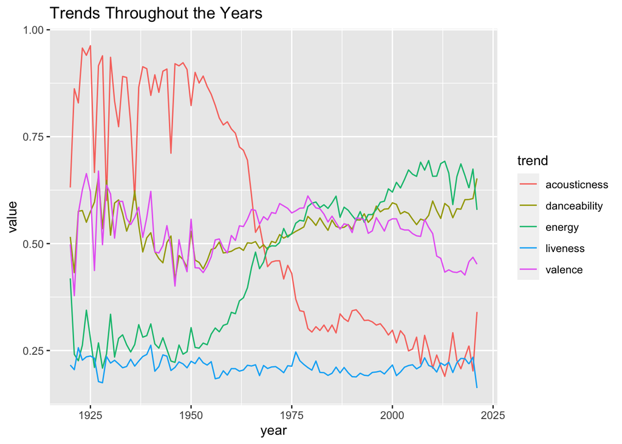

```r
#Plot for song trends
q4 <- q4 %>% pivot_longer(danceability:liveness, names_to = 'trend', values_to = 'value')

q4_plot <- q4 %>%
        ggplot(aes(x = year, y = value, color = trend)) + geom_line() +
        ggtitle("Trends Throughout the Years")

q4_plot
```

Here, I included 5 different song trends that had the same range for scale. These variables include acousticness, danceability, energy, liveness and valence. With that, I grouped everything by year and plotted these trends.

**5. What is the relationship between the acousticness and the tempo of a song?**

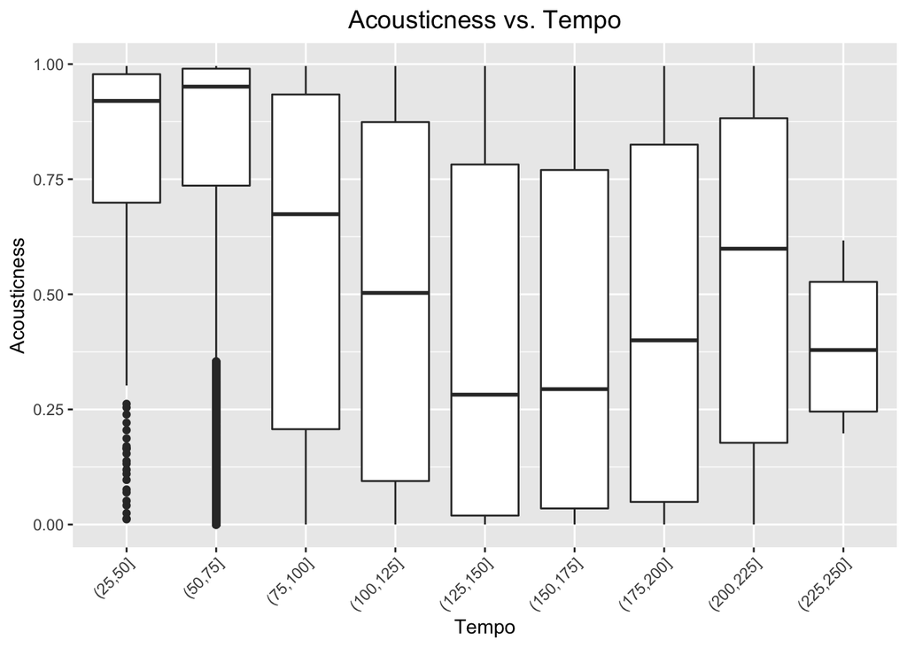

```r
q5 <- main[ , c("acousticness", "tempo")]

q5 <- q5 %>% mutate(cuts = cut(tempo, breaks = c(0, 25, 50, 75, 100, 125, 150, 175, 200, 225, 250)))

q5 <- q5 [!(q5$tempo==0.000),]

q5$cuts <- as.character(q5$cuts)

q5$cuts <- factor(q5$cuts, levels=c("(25,50]", "(50,75]", "(75,100]", "(100,125]", "(125,150]", "(150,175]", "(175,200]", "(200,225]", "(225,250]"))

ggplot(q5, aes(x = cuts, y = acousticness)) + geom_boxplot() +
      theme(axis.text.x = element_text(angle=45, hjust=1)) +
      labs(title="Acousticness vs. Tempo", x="Tempo", y="Acousticness") +
      theme(plot.title = element_text(size=14, hjust=0.5))
```

I first created a simple scatterplot for this question, however it was not very informative. I instead created grouped boxplots to show the different acousticnesses at different tempos. The tempo values are group by 25. I had to do a bit of wrangling to make this work the way I wanted. I created a subset of only the acousticness and tempo values, then mutated a new column which put the tempo values into ranged groups. I removed any songs with a tempo of 0, factored the data to order it properly in the visualization, and then created the boxplot.

With this visualization, it does appear that there are some slight trends in this relationship. Songs with a tempo between 25 and 75 are clearly much higher in acousticness than songs between 75 and 200. Interestingly, songs with a very high tempo (between 200 and 250) begin to rise again in acousticness.

**6. Are explicit songs more popular than non-explicit songs?**

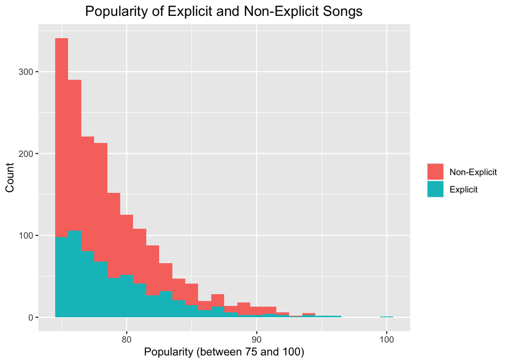

```r
main75 <- subset(main, popularity>=75)
main75$explicit <- as.character(main75$explicit)

ggplot(main75, aes(x=popularity, fill=explicit)) +
        geom_histogram(binwidth = 1) +
        labs(title="Popularity of Explicit and Non-Explicit Songs", x="Popularity (between 75 and 100)", y="Count") +
        theme(plot.title = element_text(size=14, hjust=0.5)) +
        theme(legend.title = element_blank()) +
        scale_fill_discrete(labels = c("Non-Explicit", "Explicit"))
```

For this question I overlaid the two groups onto a single histogram. This histogram only includes songs with at least a popularity rating of 75 in order to focus on the higher rated content. The explicit ratings also needed to be character arguments in order to function properly in the histogram.

Surprisingly, the non-explicit songs are generally much more popular than the explicit songs. The difference in the popularity decreases as the rating gets higher, becoming quite similar around a popularity rating of 90. The only song with a popularity rating of 100 in this dataset is explicit.

The reason I expected explicit songs to be overall more popular is likely because of the distribution of this histogram, in that the higher the popularity rating, the larger the proportion of explicit songs being popular.

**7. Who are the most popular one hit wonders?**

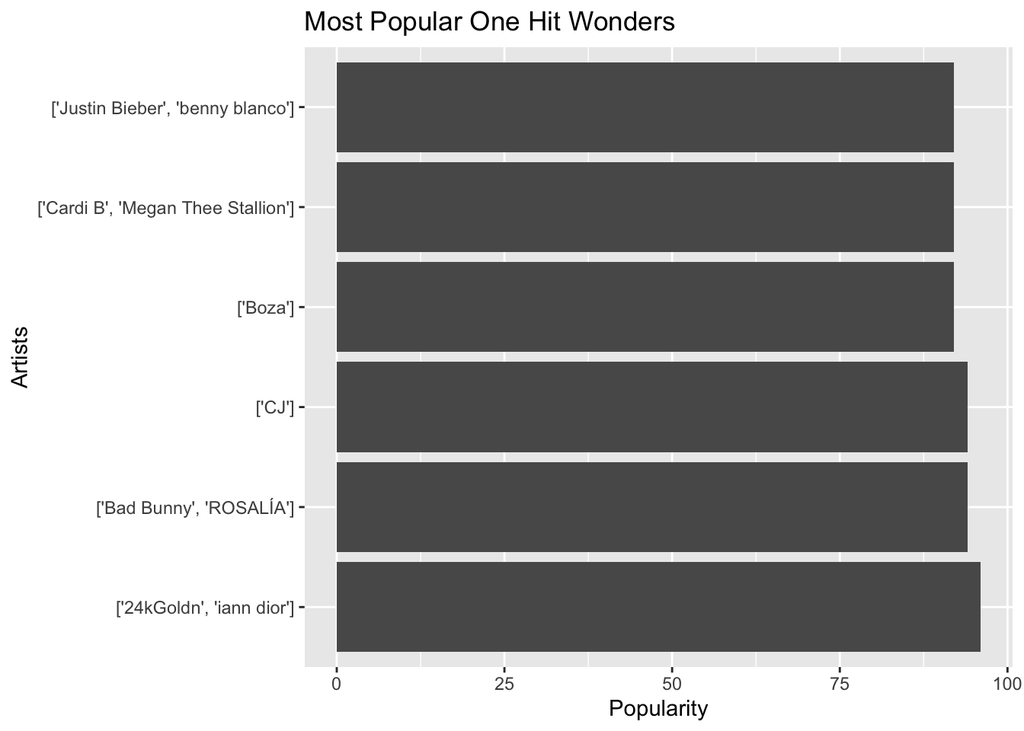

```r
one_hit_wonder <- main %>%
        group_by(artists = artists) %>%
        summarise(Num_track = n(), Popularity = mean(popularity)) %>%
        filter(Num_track == 1) %>%
        top_n(5, wt = Popularity)

ggplot(one_hit_wonder, aes(x = reorder(artists, -Popularity), weight = Popularity)) + geom_bar() + coord_cartesian(ylim=c(75,100)) +
      xlab("Artists") + ylab("Popularity") + ggtitle("Most Popular One Hit Wonders") + coord_flip()
```

```r
one_hit_names <- inner_join(main, one_hit_wonder, by = 'artists')
summarise(one_hit_names, name, artists)
```

```
## # A tibble: 6 x 2
##   name                            artists
##   <chr>                           <chr>
## 1 Mood (feat. iann dior)          ['24kGoldn', 'iann dior']
## 2 Whoopty                         ['CJ']
## 3 WAP (feat. Megan Thee Stallion) ['Cardi B', 'Megan Thee Stallion']
## 4 Lonely (with benny blanco)      ['Justin Bieber', 'benny blanco']
## 5 LA NOCHE DE ANOCHE              ['Bad Bunny', 'ROSALÍA']
## 6 Hecha Pa' Mi                    ['Boza']
```

It isn’t much of a surprise to see these one hit wonders appear on this list. Songs like “Mood”, “Whoopty” and “Lonely” are all super well known and popular songs. It will be interesting to see if the these individual artists or groups will collaborate and make some more music together.

**8. How has Post Malone’s (Tanner’s favorite artist) popularity changed over the past few years?**

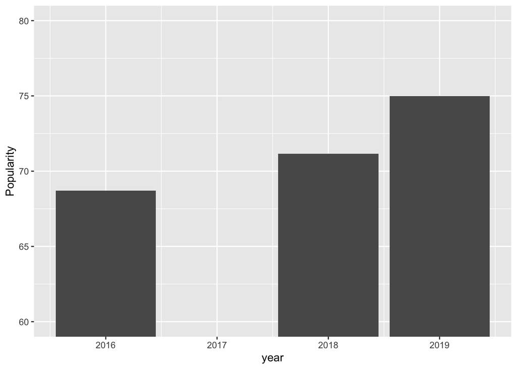

```r
dat <- main %>%
       group_by(year = year, artists = artists) %>%
       summarise(popularity = mean(popularity)) %>%
       filter(artists == "['Post Malone']")

ggplot(dat, aes(x = year, weight = popularity)) + geom_bar() + ylab('Popularity') + coord_cartesian(ylim=c(60, 80))
```

It was interesting to see the popularity of Post Malone to gradually increase in the years that he released his albums. He dropped his first album in 2016, another in 2018, and his latest one was in 2019. With each one he obviously is gaining more and more fans and it will be interesting to see his popularity after he releases his next album.

Cleaning up my data to only include necessary information I grouped by year and artist and filtered down to only include the artist I was interested in. To visualize the artist popularity over the past few years I plotted this out in barchart format.

**9. What are/were the most popular genres in the past century?**

```r
library(scales)

q9 <- by_genre %>%
       group_by(genres = genres) %>%
       summarise(popularity = mean(popularity)) %>%
       top_n(10, wt = popularity)%>%
       arrange(desc(popularity))
q9
```

```
## # A tibble: 10 x 2
##    genres             popularity
##    <chr>                   <dbl>
##  1 chinese electropop       79
##  2 korean mask singer       78
##  3 dutch rap pop            77
##  4 yaoi                     77
##  5 dong-yo                  76
##  6 rochester mn indie       76
##  7 afroswing                75.3
##  8 estonian pop             75
##  9 j-rap                    75
## 10 irish pop                74.6
```

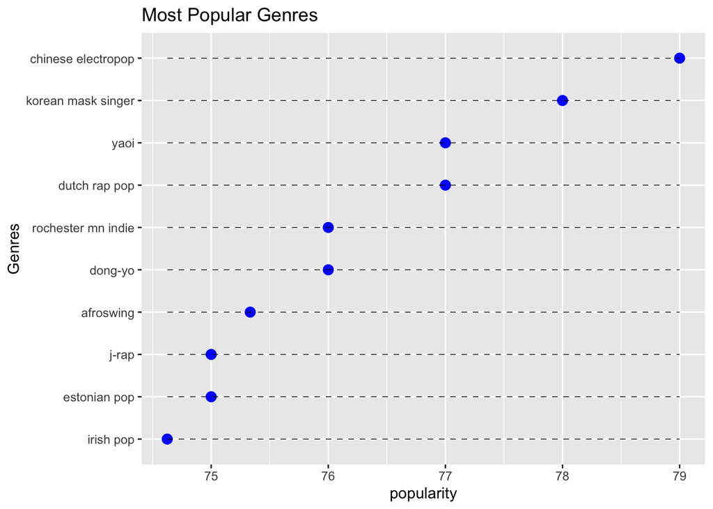

```r
ggplot(q9, aes(x=reorder(genres,popularity), y = popularity)) + geom_point(col="blue", size =3) +
       geom_segment(aes(x=genres, xend = genres, y = min(popularity), yend = max(popularity)), linetype="dashed", size=.25) +
       labs(title = "Most Popular Genres", x='Genres') +
       coord_flip()
```

To get down to the relevant data I started out by grouping by genre, summarizing popularity as the mean popularity of the genre, and pulled out the top 10 most popular from this set in descending order. Then to visualize I used a ggplot, plotting the specific genre’s popularity as a point. To enhance this graph I used geom_segment to size the graph appropriately and add horizontal dashed lines to make which I felt made it easier to read.

### **Conclusion**

**Overall, we all have concluded that…**

- Music trends and the taste of music listeners changes a lot over time!
- There are many different topics with interesting datasets to explore
- Many things go into how a song is successful
- Things that we were for sure about when making the questions turned out to be the opposite when doing the analysis

### **Contribution Statement**

**MyTien Kien**

MyTien is the team coordinator for Group 4. With that, she helped supervise everyone by making sure they contributed to the presentation, proposal, analysis and the report. She was in charge of making sure that everything was done neatly and in a timely manner. She contributed to the overall analysis by looking at the comparison between two years in terms of music patterns, as well as analyzing the trends given throughout the past century (Questions 3 & 4).

**Saketh Jonnadula**

Saketh was in charge of questions 1 and 2, which contributed to the analysis for looking into what years were the most popular and looking at how danceability and energy affects a song.

**Tanner Dunn**

Tanner was in charge of questions 7, 8, and 9 as well as finding the best data set as this topic was the one the he proposed. He contributed to the overall analysis by analyzing the most successful one hit wonders, exploring the popularity change in his favorite artist and lastly, analyzed the most popular genres.

**Ryan Pate**

Ryan was in charge of questions 5 and 6, which contributed to the analysis by looking at the relationships between different variables of music, as well as exploring the popularity of explicit versus non-explicit music.